# The Variation Case: Instructor Solution

MKT 566 · Fall 2026

## Task 1: look at the data

```r
head(df)
```

```
##   CustomerID Age Gender  Device Channel Ad_Spend Clicks Purchases Revenue
## 1          1  54      M  Mobile  Social   718.60     95         6  149.16
## 2          2  18      F  Mobile  Search   233.00     34         1   22.22
## 3          3  42      F  Mobile  Search   122.51     18         0    0.00
## 4          4  27      F Desktop  Social   198.78     19         1   13.22
## 5          5  53      F  Mobile  Social   145.19     19         4  150.48
## 6          6  35      M Desktop   Video   125.74      9         0    0.00
```

```r
nrow(df)
```

```
## [1] 1000
```

**Answer:** There are 1,000 rows, one per customer: each row records who the customer is (`Age`, `Gender`, `Device`), which ad channel reached them (`Channel`), what was spent on them (`Ad_Spend`), and how they responded (`Clicks`, `Purchases`, `Revenue`). `Gender`, `Device`, and `Channel` are categorical; the rest are numeric (`CustomerID` is just an identifier).

## Task 2: summary statistics

```r
summary(df)
```

```
##    CustomerID          Age              Gender           Device
##  Min.   :   1.0   Min.   :18.00   Length   :1000   Length   :1000
##  1st Qu.: 250.8   1st Qu.:31.00   N.unique :   2   N.unique :   2
##  Median : 500.5   Median :43.00   N.blank  :   0   N.blank  :   0
##  Mean   : 500.5   Mean   :42.51   Min.nchar:   1   Min.nchar:   6
##  3rd Qu.: 750.2   3rd Qu.:54.00   Max.nchar:   1   Max.nchar:   7
##  Max.   :1000.0   Max.   :65.00
##       Channel        Ad_Spend           Clicks         Purchases
##  Length   :1000   Min.   :   1.83   Min.   :  0.00   Min.   : 0.000
##  N.unique :   5   1st Qu.:  96.86   1st Qu.: 10.00   1st Qu.: 0.000
##  N.blank  :   0   Median : 172.25   Median : 19.00   Median : 1.000
##  Min.nchar:   5   Mean   : 216.78   Mean   : 24.17   Mean   : 1.047
##  Max.nchar:   7   3rd Qu.: 278.74   3rd Qu.: 32.00   3rd Qu.: 2.000
##                   Max.   :3875.35   Max.   :322.00   Max.   :17.000
##     Revenue
##  Min.   :  0.00
##  1st Qu.:  0.00
##  Median : 26.86
##  Mean   : 41.21
##  3rd Qu.: 61.28
##  Max.   :702.61
```

**Answer:** No missing values in any column. For `Ad_Spend`, the mean (216.8) is well above the median (172.2). From the lecture: when the mean is pulled above the median, the distribution is **right-skewed**; a minority of large values drags the mean up while the median stays with the typical customer.

## Task 3: the distribution of ad spend

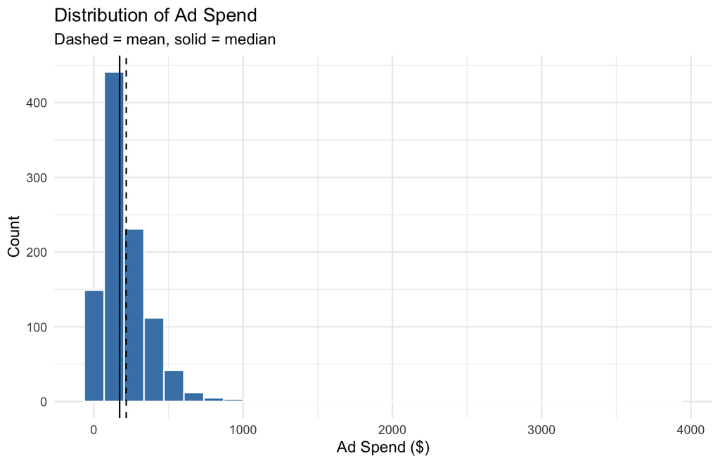

```r
ggplot(df, aes(Ad_Spend)) +
  geom_histogram(bins = 30, fill = "steelblue", color = "white") +
  geom_vline(aes(xintercept = mean(Ad_Spend)), linetype = "dashed") +
  geom_vline(aes(xintercept = median(Ad_Spend))) +
  labs(title = "Distribution of Ad Spend",
       subtitle = "Dashed = mean, solid = median",
       x = "Ad Spend ($)", y = "Count") +
  theme_minimal()
```

**Answer:** Clearly right-skewed: most customers receive modest spend, with a long tail of customers receiving several times more. The dashed mean line sits visibly to the right of the solid median line, which is exactly the skew the summary statistics hinted at. A plausible marketing strategy behind this shape: the firm spends a baseline amount on most customers and concentrates extra budget on a small group it believes is high-value (retargeting, lookalike audiences, big-ticket prospects).

## Task 4: the same chart, on a log scale

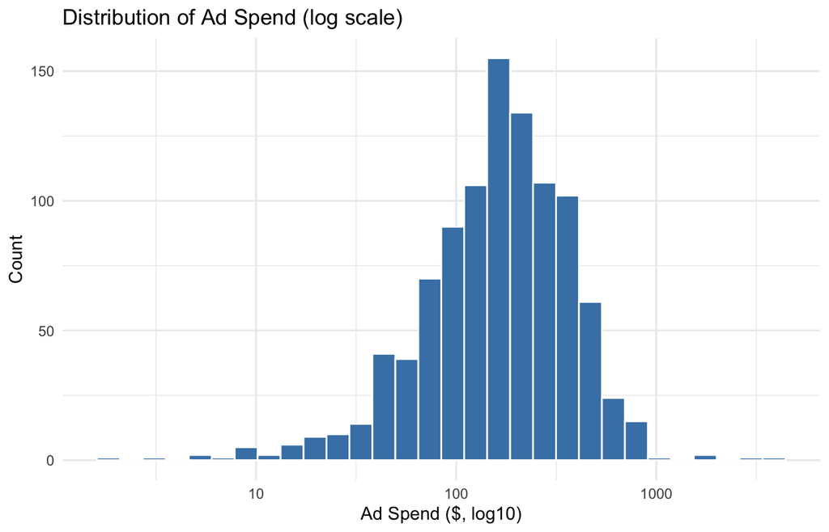

```r
ggplot(df, aes(Ad_Spend)) +
  geom_histogram(bins = 30, fill = "steelblue", color = "white") +
  scale_x_continuous(trans = "log10") +
  labs(title = "Distribution of Ad Spend (log scale)",
       x = "Ad Spend ($, log10)", y = "Count") +
  theme_minimal()
```

**Answer:** On the log scale the distribution becomes roughly symmetric and bell-shaped, so the “typical” customer is easy to read off: about $150–200. The low-spend customers, invisible in the left pile of the linear chart, are now spread out and visible. This is the lecture’s point about logs: they expand small values, compress large ones, and turn a skewed distribution into one you can actually read.

## Task 5: the channel mix

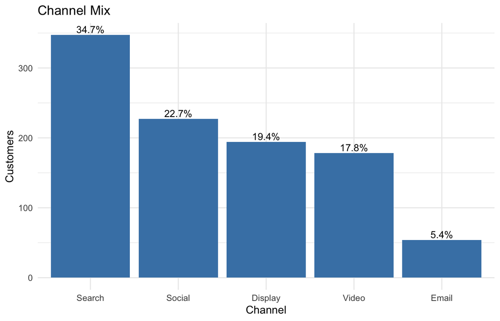

```r
df %>%
  count(Channel) %>%
  mutate(p = n / sum(n)) %>%
  ggplot(aes(reorder(Channel, -n), n)) +
  geom_col(fill = "steelblue") +
  geom_text(aes(label = percent(p, accuracy = 0.1)), vjust = -0.3, size = 3.5) +
  labs(title = "Channel Mix", x = "Channel", y = "Customers") +
  theme_minimal()
```

**Answer:** Not balanced. Search dominates (34.7%), followed by Social (22.7%), Display (19.4%), and Video (17.8%); Email is a distant last at 5.4%. The mix is plausible for an online retailer: search captures customers with existing intent, social and display do the prospecting, and email is cheap but only reaches customers the firm already knows.

## Task 6: hunting outliers

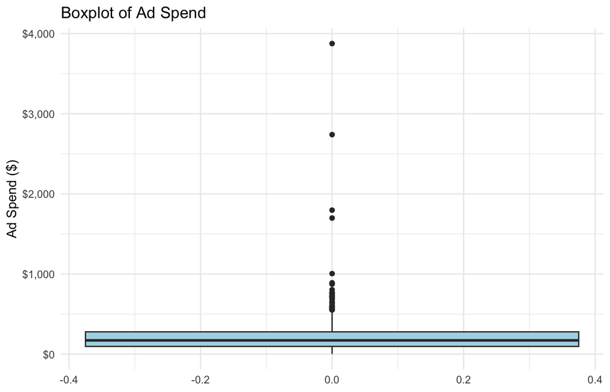

```r
ggplot(df, aes(y = Ad_Spend)) +
  geom_boxplot(fill = "lightblue") +
  scale_y_continuous(labels = dollar_format()) +
  labs(title = "Boxplot of Ad Spend", y = "Ad Spend ($)") +
  theme_minimal()
```

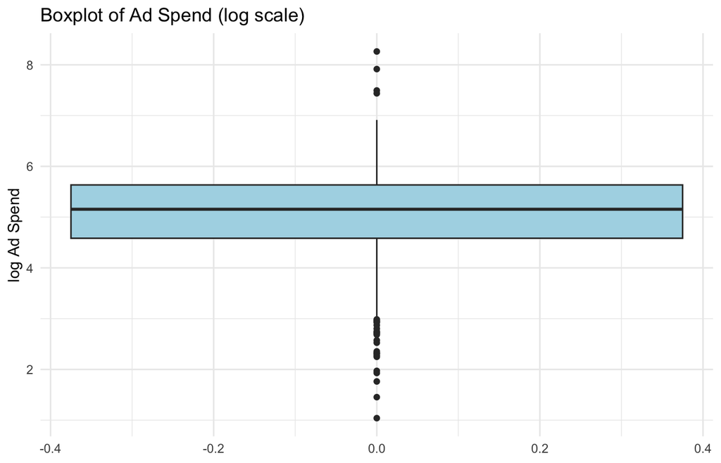

```r
ggplot(df, aes(y = log(Ad_Spend + 1))) +
  geom_boxplot(fill = "lightblue") +
  labs(title = "Boxplot of Ad Spend (log scale)", y = "log Ad Spend") +
  theme_minimal()
```

## Task 7: my own question

*Example: is ad spend targeted by device?*

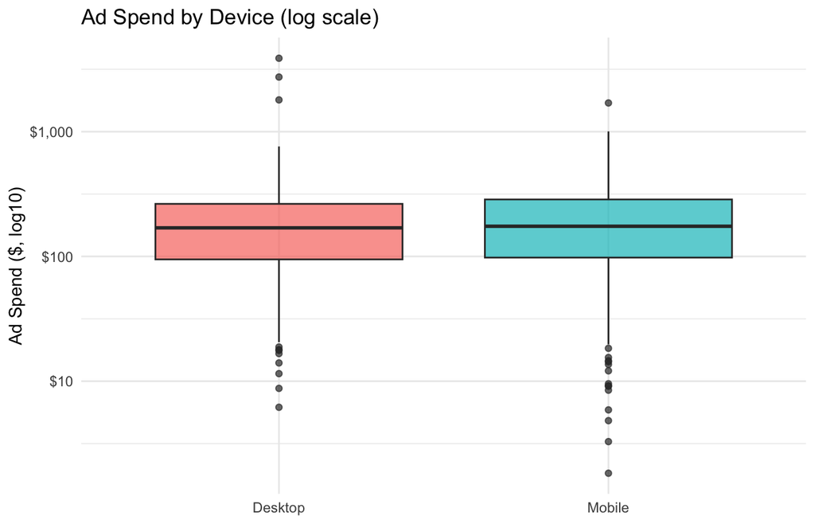

```r
ggplot(df, aes(Device, Ad_Spend, fill = Device)) +
  geom_boxplot(alpha = 0.7) +
  scale_y_continuous(trans = "log10", labels = dollar_format()) +
  labs(title = "Ad Spend by Device (log scale)",
       x = NULL, y = "Ad Spend ($, log10)") +
  theme_minimal() +
  theme(legend.position = "none")
```

**Answer:** I asked whether Mobile and Desktop customers receive different ad spend. They essentially do not: the two distributions sit on top of each other (means 214 vs. 221, medians 175 vs. 170). Spend does not appear to be targeted by device in this data, even though mobile users are 65% of customers.